# LinearRegression

Dima Mikhaylow

9/14/2021

## Questions:

#### General on regression - what is significance of "the errors are assumed to have unknown variance

#### 9. Eestimated value for the standard deviation of the error terms???? Meaning standard error of regression???

## Simple Linear Regression

We will explore the relationship between the response variable body mass (in grams), `body_mass_g`, and the predictor length of the flippers (in mm), `flipper_length_mm`.

1. Produce a scatterplot of the two variables. How would you describe the relationship between the two variables? Be sure to label the axes and give an appropriate title. Based on the appearance of the plot, does a simple linear regression appear reasonable for the data?

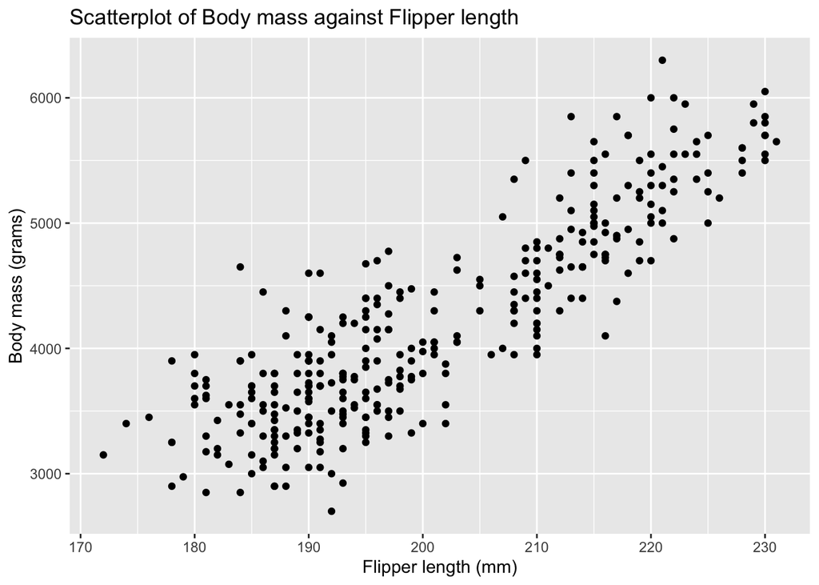

```r
ggplot(penguins, aes(x=flipper_length_mm, y=body_mass_g))+
  geom_point()+
  labs(x="Flipper length (mm)", y="Body mass (grams)",
       title="Scatterplot of Body mass against Flipper length")
```

#### Observation: yes, the data appears to be linear.

2. Produce a similar scatterplot, but with different colored plots for each species. How does this scatterplot influence your answer to the previous part?

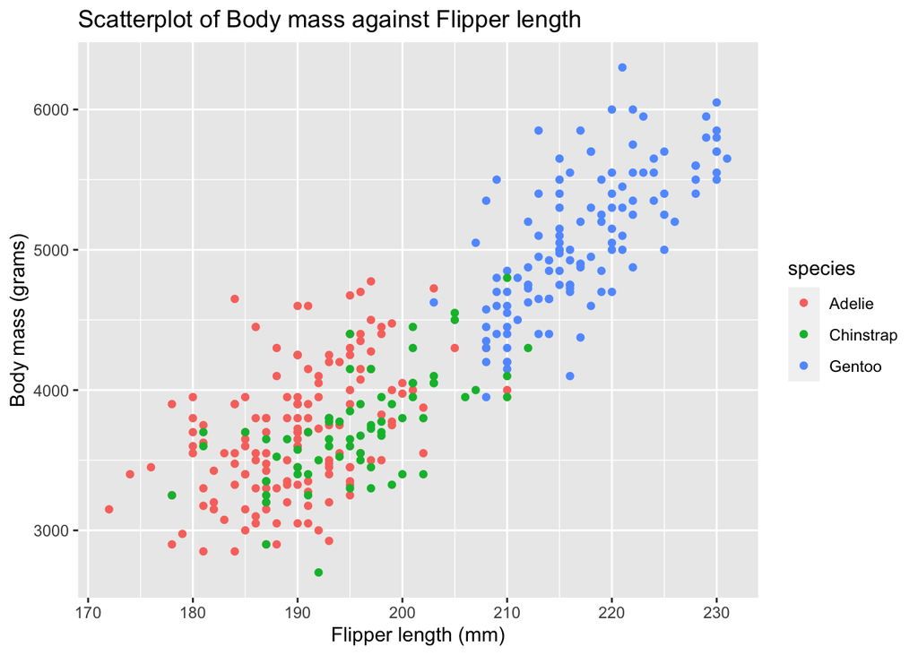

```r
ggplot(penguins, aes(x=flipper_length_mm, y=body_mass_g, colour=species))+
  geom_point()+
  labs(x="Flipper length (mm)", y="Body mass (grams)",
       title="Scatterplot of Body mass against Flipper length")
```

#### Observation: still linear data, with 2 distinct clusters: (Adelie, Chinstrap) and (Gentoo).

3. Regardless of your answer to the previous part, produce a scatterplot of body mass and flipper length for Gentoo penguins. Based on the appearance of the plot, does a simple linear regression appear reasonable for the data?

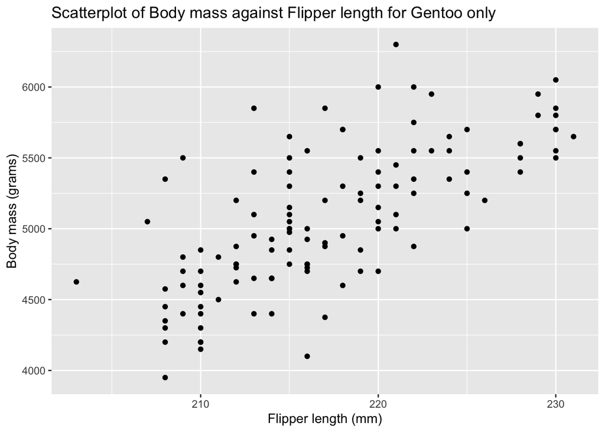

```r
ggplot(penguins[which(penguins$species=='Gentoo'), ], aes(x=flipper_length_mm, y=body_mass_g))+
  geom_point()+
  labs(x="Flipper length (mm)", y="Body mass (grams)",
       title="Scatterplot of Body mass against Flipper length for Gentoo only")
```

#### Observation: yes, linear model may work well, but I am noting significsnat variance in the data now. There may be high residuals.

4. What is the correlation between body mass and flipper length for Gentoo penguins. Interpret this correlation contextually. How reliable is this interpretation? For the rest of the questions, assume the assumptions to perform linear regression on Gentoo penguins are met.

```r
Gentoo <- na.omit(penguins[which(penguins$species=='Gentoo'),
                   c("flipper_length_mm", "body_mass_g")])
cor(Gentoo$flipper_length_mm, Gentoo$body_mass_g)
```

```
## [1] 0.7026665
```

#### Observation: some positive correlation between Mass and Flipper length, as seen on the scatterplot, is confirmed: r=0.70.

5. Use the `lm()` function to fit a linear regression for body mass and flipper length for Gentoo penguins. Write out the estimated linear regression equation.

```r
result <- lm(body_mass_g ~ flipper_length_mm, data=Gentoo)
summary(result)
```

```
##
## Call:
## lm(formula = body_mass_g ~ flipper_length_mm, data = Gentoo)
##
## Residuals:
##     Min      1Q  Median      3Q     Max
## -911.18 -235.76  -51.93  170.75 1015.71
##
## Coefficients:
##                    Estimate Std. Error t value Pr(>|t|)
## (Intercept)       -6787.281   1092.552  -6.212 7.65e-09 ***
## flipper_length_mm    54.623      5.028  10.863  < 2e-16 ***
## ---
## Signif. codes:  0 '***' 0.001 '**' 0.01 '*' 0.05 '.' 0.1 ' ' 1
##
## Residual standard error: 360.2 on 121 degrees of freedom
## Multiple R-squared:  0.4937, Adjusted R-squared:  0.4896
## F-statistic:   118 on 1 and 121 DF,  p-value: < 2.2e-16
```

6. Interpret the estimated slope contextually.

#### Observation: the slope of 54.62 suggests that for 1 mm increase of Flipper length, there will be app. 55 gram increase in Body mass.

7. Does the estimated intercept make sense contextually?

8. Report the value of R2 from this linear regression, and interpret its value contextually.

#### Observation: in this case Multiple R-squared is R2 and it is equal to 0.49.

9. What is the estimated value for the standard deviation of the error terms for this regression model?

#### ?? Residual standard error: 360.2 ??

10. For a Gentoo penguin which has a flipper length of 220mm, what is its predicted body mass in grams?

```r
mass_hat =  -6787.281 + 54.623 * 220
mass_hat
```

```
## [1] 5229.779
```

11. Produce the ANOVA table for this linear regression. Using only this table, calculate the value of R2.

```r
anova.tab <- anova(result)
anova.tab
```

```
## Analysis of Variance Table
##
## Response: body_mass_g
##                    Df   Sum Sq  Mean Sq F value    Pr(>F)
## flipper_length_mm   1 15308045 15308045  118.01 < 2.2e-16 ***
## Residuals         121 15696203   129721
## ---
## Signif. codes:  0 '***' 0.001 '**' 0.01 '*' 0.05 '.' 0.1 ' ' 1
```

```r
R2 = anova.tab$"Sum Sq"[1] / sum(anova.tab$"Sum Sq")
R2
```

```
## [1] 0.4937402
```

#### Observation: very similar to Multiple R-squared in #8

12. What are the null and alternative hypotheses for the ANOVA F test?

#### Observation: ANOVA F-test null hypothesis (H0: B1=0) is that slope is zero, hence no relationship. Alternative is that it is not zero, hence some relationship.

13. Explain how the F statistic of 118.01 is found.

```r
F_stats = anova.tab$"Sum Sq"[1]  / anova.tab$"Mean Sq"[2]
```

#### Observation: F_stats is Regression Sum of Squares divided by Mean Squared Error.

14. Write an appropriate conclusion for the ANOVA F test for this simple linear regression model.